# Final Exam 2

# Instructions

1. Only complete the sections for which you want a better score. (Complete all questions within a section.)
2. After completing the exam:
- Delete any sections that you did not complete.
- Save the exam as final-exam-2.rmd and final-exam-2.html in the 99-final-exam folder of your Probability and Inference Portfolio repo.
- Push your repo.

# 4. Continuous Distributions

Let X be distributed as a mixture normals. The `r`, `p`, and `d` functions are below. (This is our old friend `f3` from deliverable 5.)

```r
rf3 <- function(N){
  G <- sample(0:2, N, replace = TRUE, prob = c(5,3,2))
  (G==0)*rnorm(N) + (G==1)*rnorm(N,4) + (G==2)*rnorm(N,-4,2)
}

pf3 <- function(x){
  .5*pnorm(x) + .3*pnorm(x,4) + .2*pnorm(x,-4,2)
}

df3 <- function(x){
  .5*dnorm(x) + .3*dnorm(x,4) + .2*dnorm(x,-4,2)
}
```

Let Y be distirbuted as another mixture of normals. The `r`, `p`, and `d` functions are below. (This is a slightly different distribution.)

```r
rf4 <- function(N){
  G <- sample(0:2, N, replace = TRUE, prob = c(2,3,5))
  (G==0)*rnorm(N) + (G==1)*rnorm(N,4) + (G==2)*rnorm(N,-4,2)
}

pf4 <- function(x){
  .2*pnorm(x) + .3*pnorm(x,4) + .5*pnorm(x,-4,2)
}

df4 <- function(x){
  .2*dnorm(x) + .3*dnorm(x,4) + .5*dnorm(x,-4,2)
}
```

**C.** What is the .9 quantile of X?

```r
qf3 <- function(y){
    uniroot(function(x) pf3(x) - y, interval = c(-100, 100))$root
}

qf3(0.9)
```

```
## [1] 4.43077
```

**B.** Suppose that X is the distribution of a biomarker when a patient is healthy. Suppose Y is the distribution of the same biomarker when a patient has a genetic condition.

Calculate P(genetic condition is present | biomarker = 0) under the assumption that P(genetic condition) = 0.1.

```r
p <- 0.1
(df4(0)*p)/(df4(0)*p + df3(0)*(1-p))
```

```
## [1] 0.04816794
```

**A.** Generate a plot of P(genetic condition is present | biomarker = B). Let B length range from -6 to 6.

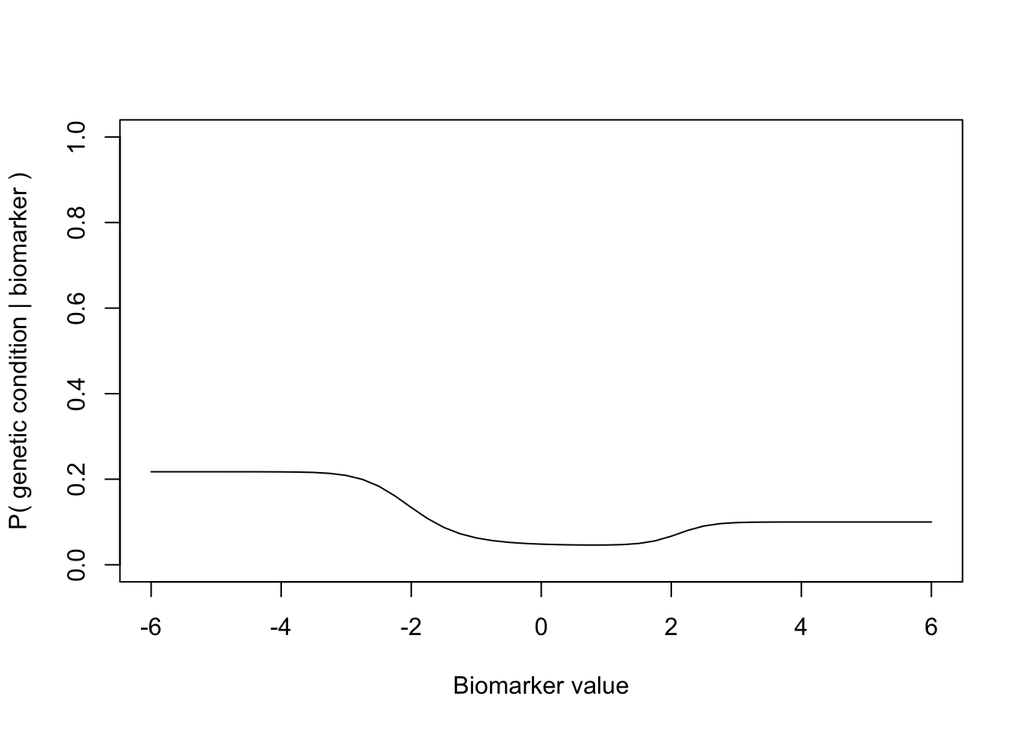

```r
B <- seq(-6, 6, by = .25)
prob_genetic_condition <- (df4(B)*p)/(df4(B)*p + df3(B)*(1-p))
plot.new()
plot.window(xlim = c(-6,6), ylim = c(0,1))
lines(B, prob_genetic_condition)
axis(1)
axis(2)
box()
title(xlab = "Biomarker value", ylab = "P( genetic condition | biomarker )")
```